# R Notebook

# Exercise 17.07

```r
read1707 <- read.csv("D:\\Xr17-07.csv")
data1707 <- data.frame(read1707)
```

## 1. Plot the scatter diagram

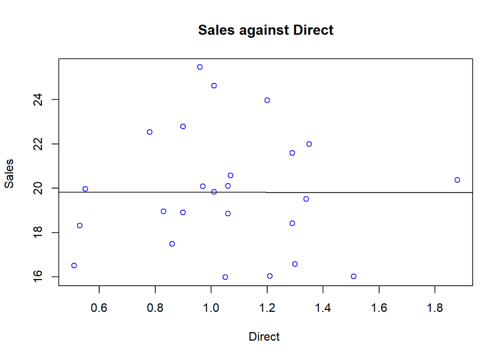

```r
Sales <- read1707$Sales
Direct <- read1707$Direct
n <- length(Sales)
plot(Direct, Sales, col = "blue", main = "Sales against Direct", xlab = "Direct ", ylab = "Sales ")
abline(lm(Sales ~ Direct))
```

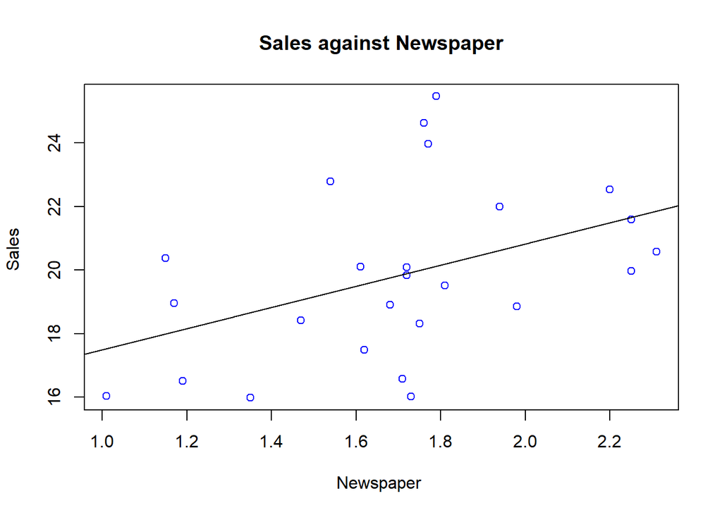

```r
Sales <- read1707$Sales
Newspaper <- read1707$Newspaper
n <- length(Sales)
plot(Newspaper, Sales, col = "blue", main = "Sales against Newspaper", xlab = "Newspaper ", ylab = "Sales ")
abline(lm(Sales ~ Newspaper))
```

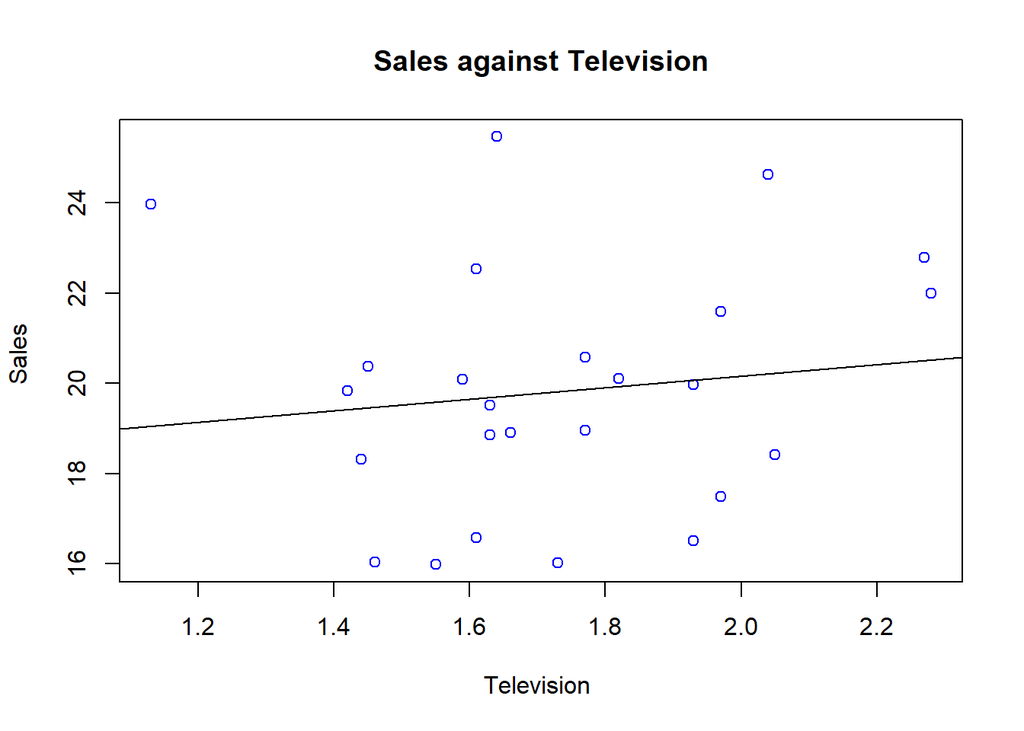

```r
Sales <- read1707$Sales
Television <- read1707$Television
n <- length(Sales)
plot(Television, Sales, col = "blue", main = "Sales against Television", xlab = "Television ", ylab = "Sales ")
abline(lm(Sales ~ Television))
```

## 2. Propose a statistical model

Suppose that Sales is related to the weekly expenditures on direct mailing (in thousands of dollars) (x1), weekly expenditures on newspaper advertising (in thousands of dollars)(x2), weekly expenditures on television commercials (x3) and the error$\epsilon$ by the following regression model:
$$y = \beta_0 + \beta_1x_1 + \beta_2x_2 + \beta_3x_3 + \epsilon$$
where y = weekly gross sales (in thousands of dollars). x1 = weekly expenditures on direct mailing (in thousands of dollars). x2 = weekly expenditures on newspaper advertising (in thousands of dollars). x3 = weekly expenditures on television commercials (in thousands of dollars) ε = error variable.

## 3. Fit the model

```r
n <- length(Sales)
Data.read1707 <- cbind(Direct, Newspaper, Television)
linearModelVar <- lm(Sales ~ Data.read1707)
cat("# # # # The regression model # # # ","\n")
```

```
## # # # # The regression model # # #
```

```r
print(summary(linearModelVar))
```

```
##
## Call:
## lm(formula = Sales ~ Data.read1707)
##
## Residuals:
##     Min      1Q  Median      3Q     Max
## -4.1592 -1.4529 -0.7043  0.9982  5.4709
##
## Coefficients:
##                         Estimate Std. Error t value Pr(>|t|)
## (Intercept)              12.3084     4.6982   2.620   0.0160 *
## Data.read1707Direct       0.5699     1.7203   0.331   0.7437
## Data.read1707Newspaper    3.3200     1.5390   2.157   0.0427 *
## Data.read1707Television   0.7322     1.9584   0.374   0.7123
## ---
## Signif. codes:  0 '***' 0.001 '**' 0.01 '*' 0.05 '.' 0.1 ' ' 1
##
## Residual standard error: 2.587 on 21 degrees of freedom
## Multiple R-squared:  0.1953, Adjusted R-squared:  0.08029
## F-statistic: 1.698 on 3 and 21 DF,  p-value: 0.1979
```

```r
ANOVA_T_lm <- anova(linearModelVar)
cat("# # # # The ANOVA Table # # # ","\n")
```

```
## # # # # The ANOVA Table # # #
```

```r
print(ANOVA_T_lm)
```

```
## Analysis of Variance Table
##
## Response: Sales
##               Df  Sum Sq Mean Sq F value Pr(>F)
## Data.read1707  3  34.104 11.3679  1.6984 0.1979
## Residuals     21 140.560  6.6933
```

The regression line is y_head = 12.3084+0.5699$x_1$+3.3200$x_2$+0.7322$x_3$ ,

## 4. Residual analysis

Standardized Residuals

```r
SE <- standarized_errors_MR(Sales, Data.read1707)[,1]
h <- standarized_errors_MR(Sales, Data.read1707)[,2]
D <- standarized_errors_MR(Sales, Data.read1707)[,3]
cat("# # # # The Standardized Errors # # # ","\n")
```

```
## # # # # The Standardized Errors # # #
```

```r
print(SE)
```

```
##  [1] -1.03367871 -0.15875710  2.17333728 -1.72586989 -1.33435959
##  [6]  0.20193694 -0.86276795  0.54883639  1.92058800  0.42493667
## [11]  1.79248761 -0.30533233 -0.67727382 -0.73229536  1.40502044
## [16]  1.06302541 -0.67761077 -0.50832595 -0.60572822 -0.28012280
## [21]  0.14099331  0.07981823 -0.42160983  0.36478964 -0.55756421
```

```r
cat("# # # # hi # # # ","\n")
```

```
## # # # # hi # # #
```

```r
print(h)
```

```
##  [1] 0.09530176 0.20613382 0.05326788 0.13231657 0.07217891 0.04797128
##  [7] 0.08999550 0.16915504 0.25666639 0.17551472 0.09191321 0.08722904
## [13] 0.23259404 0.07762228 0.22798756 0.40546419 0.31309362 0.22895732
## [19] 0.22438893 0.05550430 0.05688955 0.09987866 0.15121917 0.27770730
## [25] 0.17104896
```

```r
cat("# # # # Di # # # ","\n")
```

```
## # # # # Di # # #
```

```r
print(D)
```

```
##  [1] 0.0562779595 0.0032721883 0.1328808974 0.2271114564 0.0692567079
##  [6] 0.0010273840 0.0368074114 0.0306634321 0.6368302046 0.0192198087
## [11] 0.1626046218 0.0044546627 0.0695139546 0.0225642112 0.2914889760
## [16] 0.3853290766 0.1046423010 0.0383646012 0.0530741513 0.0023056509
## [21] 0.0005995659 0.0003534645 0.0158344423 0.0255816805 0.0320738689
```

Non-normality

$H_0$ :Errors are normally distributed

$H_1$:Errors are not normally distributed

```r
Chi_normal_value <- Chi_Square_Normal_Test(SE, 4)
```

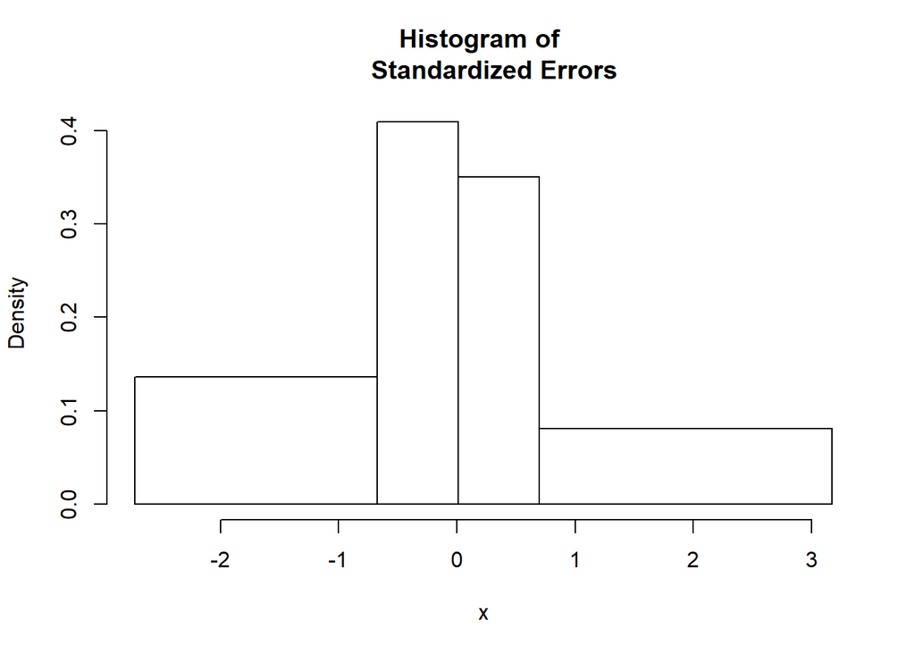

```r
print(Chi_normal_value)
```

```
## X-squared
## 0.5071225
```

since p_value = 0.5071225 > 0.05. We can assume that errors are normally distributed.

Heteroscedasticity and homoscedasticity

$H_0$:Homoscedasticity

$H_1$:Heteroscedasticity

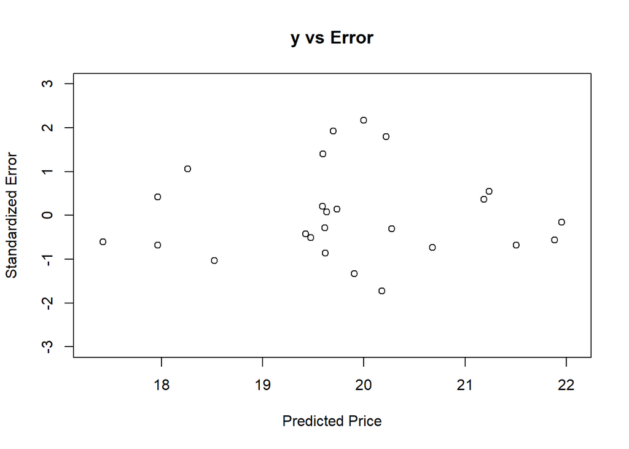

```r
Hetero_plot(Sales,Data.read1707,3)
```

It appears that the variation is constant and the mean is around 0.

Non-independence of the Error Variable

```r
Run_Test_Result <- Run_Test(SE)
```

```
##  [1] FALSE  TRUE  TRUE FALSE FALSE  TRUE FALSE  TRUE  TRUE  TRUE  TRUE
## [12] FALSE FALSE FALSE  TRUE  TRUE FALSE FALSE FALSE FALSE  TRUE  TRUE
## [23] FALSE  TRUE FALSE
```

```r
cat("     ","\n")
```

```r
cat("# # # # The Run Test # # # ","\n")
```

```
## # # # # The Run Test # # #
```

```r
print(Run_Test_Result)
```

```
## [1] 12.0000000 13.0000000 13.0000000 13.4800000  2.4432765 -0.1964575
## [7]  0.8442521
```

Because 19 > R = 13 > 8, do not rejected H0. We can assume that samples are randomly selected.

Outliers and onfluential observations

```r
cat("# # # # Outliers # # # ","\n")
```

```
## # # # # Outliers # # #
```

```r
as.data.frame(data1707[abs(SE) > 2,])
```

|  | Sales | Direct | Newspaper | Television |
| --- | --- | --- | --- | --- |
| 3 | 25.47 | 0.96 | 1.79 | 1.64 |

There is 1 possible outlier, which is (25.47, 0.96, 1.79, 1.64), since its standardized residual is bigger than 2 or less than -2.

Influential observation

```r
n <- length(Sales)
Data.Inn_Profit <- cbind(Direct, Newspaper, Television)
h <- standarized_errors_MR(Sales, Data.Inn_Profit)[,2]
cat("     ","\n")
```

```r
cat("# # # # hii # # # ","\n")
```

```
## # # # # hii # # #
```

```r
print(h)
```

```
##  [1] 0.09530176 0.20613382 0.05326788 0.13231657 0.07217891 0.04797128
##  [7] 0.08999550 0.16915504 0.25666639 0.17551472 0.09191321 0.08722904
## [13] 0.23259404 0.07762228 0.22798756 0.40546419 0.31309362 0.22895732
## [19] 0.22438893 0.05550430 0.05688955 0.09987866 0.15121917 0.27770730
## [25] 0.17104896
```

```r
n <- length(h)
cat("     ","\n")
```

```r
cat("# # # # Influential Observations by h # # # ","\n")
```

```
## # # # # Influential Observations by h # # #
```

```r
k <- dim(Data.Inn_Profit)[2]
Inf_Obs <- h > 3*(k+1)/n
print(Inf_Obs)
```

```
##  [1] FALSE FALSE FALSE FALSE FALSE FALSE FALSE FALSE FALSE FALSE FALSE
## [12] FALSE FALSE FALSE FALSE FALSE FALSE FALSE FALSE FALSE FALSE FALSE
## [23] FALSE FALSE FALSE
```

```r
D <- standarized_errors_MR(Sales, Data.Inn_Profit)[,3]
cat(" ","\n")
```

```r
cat("# # # # Cook's Distance # # # ","\n")
```

```
## # # # # Cook's Distance # # #
```

```r
print(D)
```

```
##  [1] 0.0562779595 0.0032721883 0.1328808974 0.2271114564 0.0692567079
##  [6] 0.0010273840 0.0368074114 0.0306634321 0.6368302046 0.0192198087
## [11] 0.1626046218 0.0044546627 0.0695139546 0.0225642112 0.2914889760
## [16] 0.3853290766 0.1046423010 0.0383646012 0.0530741513 0.0023056509
## [21] 0.0005995659 0.0003534645 0.0158344423 0.0255816805 0.0320738689
```

```r
cat("     ","\n")
```

```r
cat("# # # # Influential Observations by Cook's Distance # # # ","\n")
```

```
## # # # # Influential Observations by Cook's Distance # # #
```

```r
Inf_Obs <- D > 1
print(Inf_Obs)
```

```
##  [1] FALSE FALSE FALSE FALSE FALSE FALSE FALSE FALSE FALSE FALSE FALSE
## [12] FALSE FALSE FALSE FALSE FALSE FALSE FALSE FALSE FALSE FALSE FALSE
## [23] FALSE FALSE FALSE
```

There is no influential observation according to both Leverage and Cook’s distance.